# RNA-Seq Vignette

Kent Riemondy RBI

March 14, 2017

## Overview

1. RNA-Seq Analysis with DESeq2
2. Exploratory Analysis

## Install Software

```r
## try http:// if https:// URLs are not supported
source("https://bioconductor.org/biocLite.R")
biocLite()

source("https://bioconductor.org/biocLite.R")
biocLite(c("DESeq2"))
```

```r
library(tidyverse)
library(DESeq2)
```

## Experimental Details

RNA-Seq libraries were taken from a [study](https://www.ncbi.nlm.nih.gov/pmc/articles/PMC4190017/) on the Yeast Metabolic Cycle (YMC). Yeast cultures spontaneously will synchronize their metabolism when grown under limiting glucose conditions. The yeast will cycle through oxidative and reductive stages and exhibit dramatic oscillations in gene expression throughout the cycle.

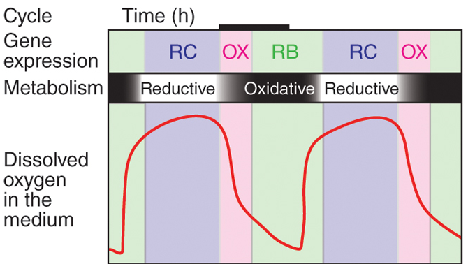

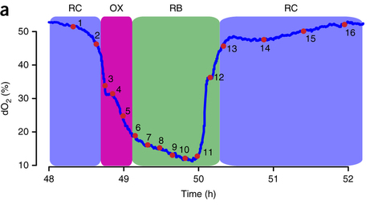

I downloaded RNA-Seq data in fastq format through the Gene Expression Omnibus ([GEO](https://www.ncbi.nlm.nih.gov/geo/query/acc.cgi?acc=GSE52339)), using the `fastq-dump` command line tool from the `sra-toolkit`.

Libraries 8-10, and 13-15 were downloaded and aligned to the Cerevisae genome using tophat following the methods described in the paper.

## FeatureCounts

First let’s create a set of variables that list where our annotation files are located and our BAM alignment files.

```r
# make variable that points to our annotation
gtf <- "dbases/genes.gtf"

# list.files will make a vector of file names
bams <- list.files("data/bams/",
            full.names = T,
            pattern = "subsampled.bam$",
            recursive = T)

#run featureCounts
#fc_SE <- featureCounts(files = bams,
#                       annot.ext=gtf,
#                       isGTFAnnotationFile = TRUE,
#                       GTF.featureType="exon",
#                       GTF.attrType="gene_id")

# read in count matrix generated by featureCounts
count_matrix <- "https://github.com/MOLB7621/class-13/raw/master/counts.txt"
counts <- read.table(count_matrix, sep = "\t", row.names = 1)
# generate list to mimic featureCounts object
fc_SE <- list(counts = counts)
```

## DESeq2

Next, we’ll use `DESeq2` to identify genes that are significantly differentially expressed between the middle and late time points during the `YMC`.

```r
metadata <- read_tsv("data/metadata.txt")
metadata$files <- bams
metadata <- mutate(metadata, files = bams)

metadata$stage <- factor(c(rep("RB", 3),
                          rep("RC", 3)))

colnames(fc_SE$counts) <- metadata$time

dds <- DESeqDataSetFromMatrix(countData = fc_SE$counts,
                              colData = metadata,
                              design = ~ stage)
dds <- DESeq(dds)
res <- results(dds)
res
```

```
## log2 fold change (MAP): stage RC vs RB
## Wald test p-value: stage RC vs RB
## DataFrame with 7130 rows and 6 columns
##             baseMean log2FoldChange     lfcSE        stat     pvalue
##            <numeric>      <numeric> <numeric>   <numeric>  <numeric>
## R0010W    77.6654487   -0.164965949 0.2122151  -0.7773525 0.43695085
## R0020C    96.3189767    0.118605560 0.1987642   0.5967150 0.55069764
## R0030W    46.8460767    0.350572740 0.2642950   1.3264451 0.18469232
## R0040C    62.9979287   -0.375268208 0.2203248  -1.7032499 0.08852131
## YAL069W    0.3339252    0.005808128 0.3059325   0.0189850 0.98485307
## ...              ...            ...       ...         ...        ...
## YPR201W    8.3144233    0.483401546 0.4396808  1.09943756  0.2715773
## YPR202W    0.2832139    0.005279431 0.2932554  0.01800285  0.9856366
## YPR203W    0.0000000             NA        NA          NA         NA
## YPR204W    2.0219392   -0.167258690 0.4878446 -0.34285240  0.7317095
## YPR204C-A  0.0000000             NA        NA          NA         NA
##                padj
##           <numeric>
## R0010W    0.7744718
## R0020C    0.8358522
## R0030W    0.5347206
## R0040C    0.3547089
## YAL069W          NA
## ...             ...
## YPR201W   0.6351172
## YPR202W          NA
## YPR203W          NA
## YPR204W          NA
## YPR204C-A        NA
```

The output from DESeq is in a non-dataframe object, so next we’ll transform it into a dataframe.

```r
res <- as.data.frame(res) %>%
  mutate(genes = rownames(res)) %>%
  select(genes, everything()) %>%
  as_data_frame()
```

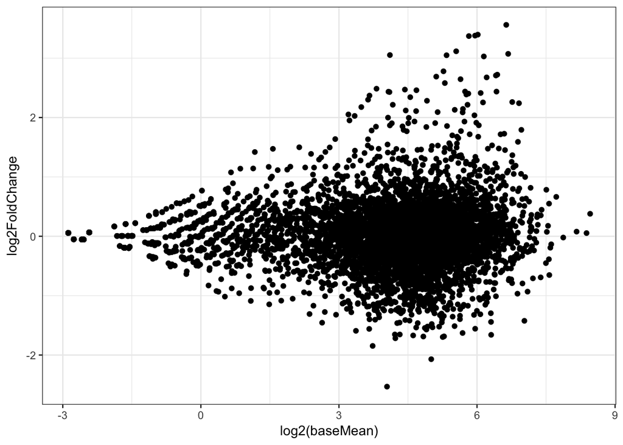

```r
# make MA plot
ggplot(res, aes(log2(baseMean), log2FoldChange)) +
  geom_point() + theme_bw()
```

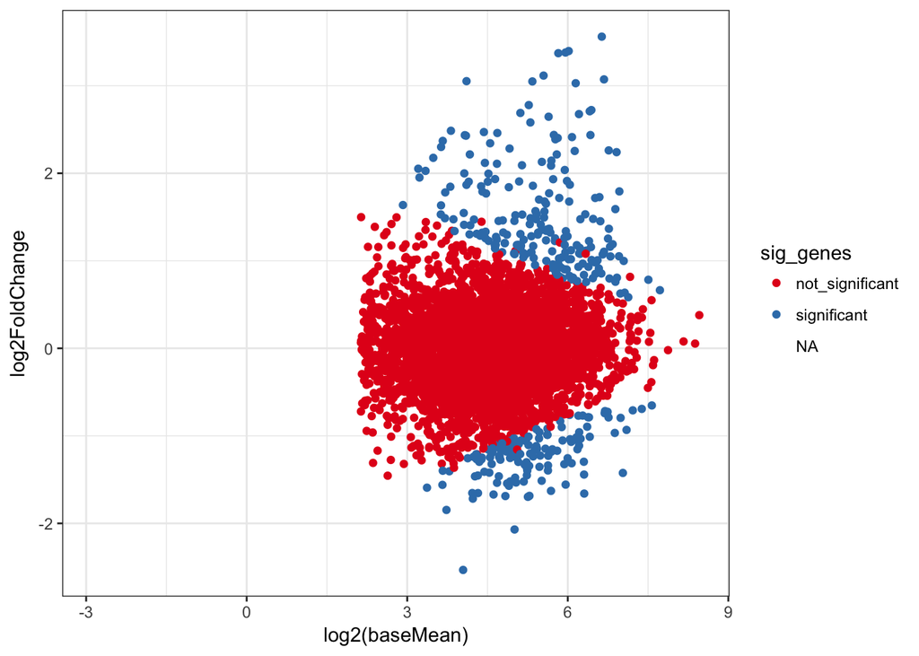

```r
# ifelse is a useful function for classifying rows
res <- res %>%
  mutate(sig_genes = ifelse(padj < 0.01,
                            "significant",
                            "not_significant"))

# plot with colour
ggplot(res, aes(log2(baseMean), log2FoldChange, colour = sig_genes)) +
  geom_point() +
  scale_color_brewer(palette = "Set1") +
  theme_bw()
```

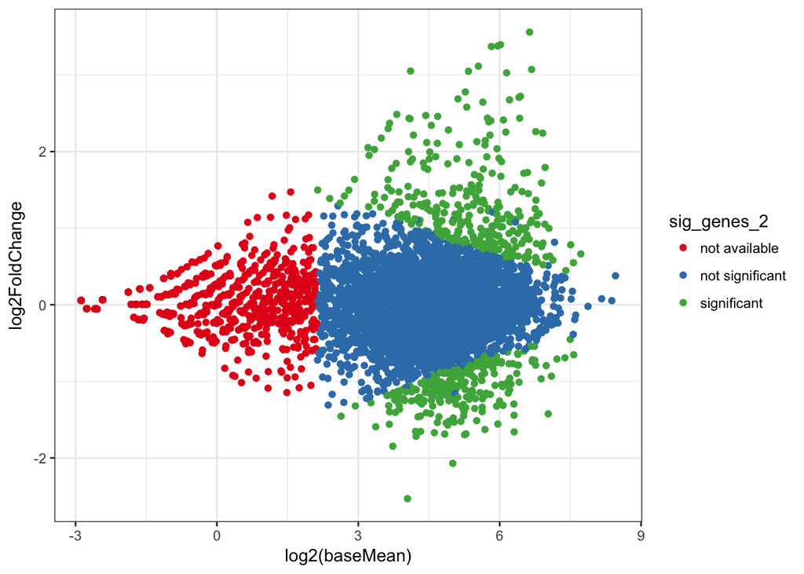

```r
res %>%
  mutate(sig_genes_2 = ifelse(is.na(padj),
                              "not available",
                              ifelse(padj < 0.05,
                                     "significant",
                                     "not significant"))) -> res2

# plot with colour and color NAs
ggplot(res2, aes(log2(baseMean), log2FoldChange, colour = sig_genes_2)) +
  geom_point() +
  scale_color_brewer(palette = "Set1") +
  theme_bw()
```

```r
res %>%
  group_by(sig_genes) %>%
  summarize(sig = n())
```

```
## # A tibble: 3 × 2
##         sig_genes   sig
##             <chr> <int>
## 1 not_significant  4956
## 2     significant   348
## 3            <NA>  1826
```

## Annotate Genes

Now that we have a tidy dataset of differentially expressed genes, let’s annotate them with additional information. [Ensembl](http://uswest.ensembl.org/index.html) has an easy to use interface called `BioMart` that is useful to downloading information about genes.

Go to BioMart and download the following annotations for Yeast: - Gene ID - Associated Gene Name - GO Term Accession  
- GO Term Name

Exercises:

1. Join the `res` table with the annotations downloaded from BioMart
2. Identify the most common GO term names for `GO domain == biological_process` for significantly DE genes, and not significant genes.
3. What is the most differentially expressed gene that is involved in `oxidation-reduction process`? First find most significant, then find most downregulated and also significant.

```r
annotations <- read_tsv("dbases/mart_export.txt.gz")
annotations <- dplyr::rename(annotations,
                      genes = `Gene ID`,
                      gene_name = `Associated Gene Name`,
                      go_term_id = `GO Term Accession`,
                      go_term = `GO Term Name`,
                      go_domain = `GO domain`)

res_annotated <- left_join(res, annotations, by = "genes")
```

```r
dplyr::filter(res_annotated, go_domain == "biological_process") %>%
  group_by(sig_genes, go_term) %>%
  summarize(count_of_term = n()) %>%
  arrange(desc(count_of_term)) %>%
  na.omit() %>%
  dplyr::slice(1:5)
```

```
## Source: local data frame [10 x 3]
## Groups: sig_genes [2]
##
##          sig_genes                                    go_term
##              <chr>                                      <chr>
## 1  not_significant                         biological_process
## 2  not_significant                                  transport
## 3  not_significant regulation of transcription, DNA-templated
## 4  not_significant               transcription, DNA-templated
## 5  not_significant                          metabolic process
## 6      significant                         biological_process
## 7      significant                oxidation-reduction process
## 8      significant                          metabolic process
## 9      significant                                  transport
## 10     significant                                translation
## # ... with 1 more variables: count_of_term <int>
```

```r
dplyr::filter(res_annotated, go_term == "oxidation-reduction process") %>%
  arrange(padj) %>%
  dplyr::slice(1)
```

```
## # A tibble: 1 × 12
##     genes baseMean log2FoldChange    lfcSE     stat      pvalue
##     <chr>    <dbl>          <dbl>    <dbl>    <dbl>       <dbl>
## 1 YKR009C 99.40837       3.560776 0.254191 14.00827 1.38749e-44
## # ... with 6 more variables: padj <dbl>, sig_genes <chr>, gene_name <chr>,
## #   go_term_id <chr>, go_term <chr>, go_domain <chr>
```

```r
dplyr::filter(res_annotated,
              go_term == "oxidation-reduction process",
              padj < 0.05) %>%
  arrange(log2FoldChange) %>%
  dplyr::slice(1)
```

```
## # A tibble: 1 × 12
##     genes baseMean log2FoldChange     lfcSE      stat       pvalue
##     <chr>    <dbl>          <dbl>     <dbl>     <dbl>        <dbl>
## 1 YML087C 24.46564      -1.670032 0.3377284 -4.944896 7.618439e-07
## # ... with 6 more variables: padj <dbl>, sig_genes <chr>, gene_name <chr>,
## #   go_term_id <chr>, go_term <chr>, go_domain <chr>
```